# Meta-analysis physiological costs of hibernation: Report 2 - Immune parameters

Pablo Capilla-Lasheras

2025-04-07

This [R Markdown](http://rmarkdown.rstudio.com) Notebook contains the initial meta-analysis for the project ‘physiological ’costs’ of hibernation.

## Dataset and calculation of effect sizes

The dataset for this meta-analysis has been collected after a literature search by Pablo Burraco, Marko Prokic and Tamara Petrovic. It contains data on physiological effects of hibernation in different systems. Here a quick snapshot of the first lines of the dataset:

|  | Study | Year | Study_ID | Species | Family | Genus | Common.name | Type_of_animal | Thermoregulation | Class | Ver_Invert | Developmental_stage | Location | Experiment_venue | Biological.process | Tissue | Experimental_manipulation | Experimental.value | Biomarker_category | Specific_marker | Unit | Euthermia_N | Euthermia_M | Euthermia_SD | Euthermia_SE | Hib_N | Hib_M | Hib_SD | Hib_SE | … |
| --- | --- | --- | --- | --- | --- | --- | --- | --- | --- | --- | --- | --- | --- | --- | --- | --- | --- | --- | --- | --- | --- | --- | --- | --- | --- | --- | --- | --- | --- | --- |
| 1 | Cooper et al 2016 | 2016 | study516 | Ictidomys tridecemlineatus | Sciuridae | Ictidomys | thirteen-lined ground squirrel | Rodent | Endothermic | Mammalia | Vertebrate | adult | United States | Captive | Hibernation | blood | none | none | Innate | Basophils | 10^3 uL | 9 | 2.000000e-02 | 0.0700000 | NA | 10 | 0.000000e+00 | 0.0000000 | NA | … |
| 2 | Bohr et al 2014 | 2014 | study543 | Ictidomys tridecemlineatus | Sciuridae | Ictidomys | thirteen-lined ground squirrel | Rodent | Endothermic | Mammalia | Vertebrate | adult | United States | laboratory | Hibernation | lung | none | none | Innate | E-selectin | Normalized Densitometric Units | 6 | 5.118959e-02 | NA | 2.743494e-02 | 6 | 6.390335e-02 | NA | 2.040892e-02 | … |
| 3 | Kurtz and Carey 2007 | 2007 | study632 | Ictidomys tridecemlineatus | Sciuridae | Ictidomys | thirteen-lined ground squirrel | Rodent | Endothermic | Mammalia | Vertebrate | adult | United States | laboratory | Hibernation | gut | none | none | Adaptive | IgA | densitometric units | 14 | 5.844749e-02 | NA | 2.739726e-02 | 6 | 9.479452e-01 | NA | 7.305936e-02 | … |
| 4 | Kurtz and Carey 2007 | 2007 | study632 | Ictidomys tridecemlineatus | Sciuridae | Ictidomys | thirteen-lined ground squirrel | Rodent | Endothermic | Mammalia | Vertebrate | adult | United States | laboratory | Hibernation | gut | none | none | Adaptive | IgA | densitometric units | 14 | 5.844749e-02 | NA | 2.739726e-02 | 6 | NA | NA | NA | … |
| 5 | Talaei et al 2012 | 2012 | study678 | Mesocricetus auratus | Cricetidae | Phodopus | Syrian hamster | Rodent | Endothermic | Mammalia | Vertebrate | NA | Netherlands | laboratory | Hibernation | lung | none | none | Both | NF-kB | expression | 4 | 6.473684e-02 | NA | 2.052632e-02 | 4 | 1.389474e-01 | 0.1721053 | 3.315789e-02 | … |
| 6 | Talaei et al 2012 | 2012 | study678 | Mesocricetus auratus | Cricetidae | Phodopus | Syrian hamster | Rodent | Endothermic | Mammalia | Vertebrate | NA | Netherlands | laboratory | Hibernation | lung | none | none | Both | NF-kB | expression | 4 | 6.473684e-02 | NA | 2.052632e-02 | 4 | 9.631579e-02 | 0.1136842 | 1.736842e-02 | … |
| 7 | Talaei et al 2012 | 2012 | study678 | Mesocricetus auratus | Cricetidae | Phodopus | Syrian hamster | Rodent | Endothermic | Mammalia | Vertebrate | NA | Netherlands | laboratory | Hibernation | lung | none | none | Both | VCAM-1 | expression | 4 | 9.767442e-02 | NA | 1.395349e-02 | 4 | 1.430233e-01 | 0.1866279 | 4.360465e-02 | … |
| 8 | Talaei et al 2012 | 2012 | study678 | Mesocricetus auratus | Cricetidae | Phodopus | Syrian hamster | Rodent | Endothermic | Mammalia | Vertebrate | NA | Netherlands | laboratory | Hibernation | lung | none | none | Both | VCAM-1 | expression | 4 | 9.767442e-02 | NA | 1.395349e-02 | 4 | 1.447674e-01 | 0.1988372 | 5.406977e-02 | … |
| 9 | Cooper et al 2016 | 2016 | study516 | Ictidomys tridecemlineatus | Sciuridae | Ictidomys | thirteen-lined ground squirrel | Rodent | Endothermic | Mammalia | Vertebrate | adult | United States | Captive | Hibernation | blood | none | none | Innate | Eosinophils | 10^3 uL | 9 | 1.200000e-01 | 0.1900000 | NA | 10 | 1.000000e-02 | 0.0100000 | NA | … |
| 10 | Schwanz et al. 2011 | 2011 | study647 | Chrysemys picta | Emydidae | Chrysemys | painted turtle | Turtle | Ectothermic | Reptilia | Vertebrate | adult_male | United States | field/captive | Hibernation | blood | none | none | Innate | Monocytes | 10^3 uL | 19 | 1.343284e-01 | NA | 4.776119e-02 | 19 | 1.313433e-01 | NA | 4.179104e-02 | … |

[output cut: 231 more lines]

As a summary of the *initial dataset*:

- Number of studies: 20
- Number of species: 12

For this meta-analysis, I am going to include all immune (IM) markers and calculate the standarised mean difference (g) as the effect size of analysis comparing **hibernation** *versus* **euthermia**. Positive SMD values indicate higher IM values in *hibernation* while negative SMD indicate lower IM values in hibernation. This is a summary of the effect size calculation based on the dataset above:

Summary of SMD effect size and number of observations included in the meta-analysis:

```
##      Min.   1st Qu.    Median      Mean   3rd Qu.      Max.
## -8.157125 -0.911860  0.074336  0.004974  0.890436  9.378137
```

- Number of observation with non-missing SMD: 224
- Number of studies in the dataset for analysis: 17
- Number of species in the dataset for analysis: 10

## Initial meta-analysis:

This initial model contains only the intercept and five random effects to account for variation between between classes, families, species, between studies and within studies beyond sampling variance.

```r
model_SMD <- rma.mv(yi = SMDH,
                     V = SMDH.sv,
                     mods = ~ 1,
                     random = list(~1|Study_ID,
                                   ~1|Class,
                                   ~1|Family,
                                   ~1|Species,
                                   ~1|obsID),
                     data=df_SMD,
                     method="REML")
```

```
##
## Multivariate Meta-Analysis Model (k = 224; method: REML)
##
##    logLik   Deviance        AIC        BIC       AICc
## -386.5568   773.1136   785.1136   805.5566   785.5025
##
## Variance Components:
##
##             estim    sqrt  nlvls  fixed    factor
## sigma^2.1  0.7840  0.8854     17     no  Study_ID
## sigma^2.2  0.8637  0.9294      3     no     Class
## sigma^2.3  0.0000  0.0002      8     no    Family
## sigma^2.4  0.0000  0.0001     10     no   Species
## sigma^2.5  0.5704  0.7552    224     no     obsID
##
## Test for Heterogeneity:
## Q(df = 223) = 755.6201, p-val < .0001
##
## Model Results:
##
## estimate      se     zval    pval    ci.lb   ci.ub
##  -0.7613  0.6367  -1.1958  0.2318  -2.0091  0.4865
##
## ---
## Signif. codes:  0 '***' 0.001 '**' 0.01 '*' 0.05 '.' 0.1 ' ' 1
```

Proportion of variation left after accounting for sampling variance and proportion accounted by each random effect:

| Variable | i2_value_percentage |
| --- | --- |
| I2_Total | 85.923 |
| I2_Study_ID | 30.369 |
| I2_Class | 33.459 |
| I2_Family | 0.000 |
| I2_Species | 0.000 |
| I2_obsID | 22.095 |

### Plot of results of intercept-only model:

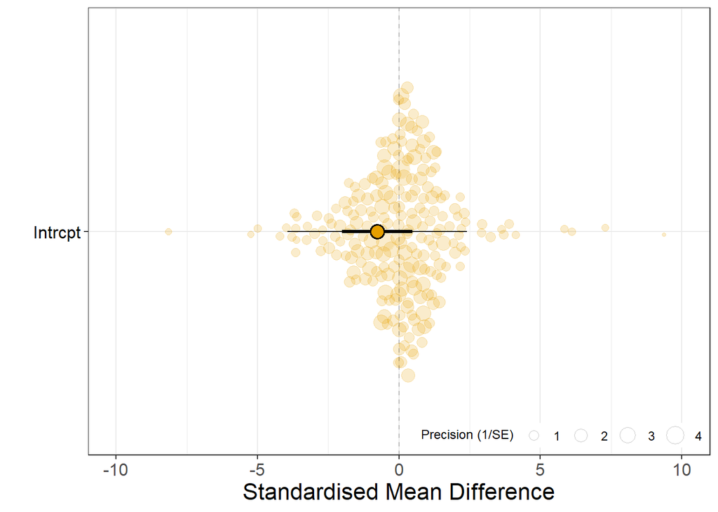

### Publication bias: small-study effects

```
##
## Multivariate Meta-Analysis Model (k = 224; method: REML)
##
##    logLik   Deviance        AIC        BIC       AICc
## -384.4760   768.9520   782.9520   806.7707   783.4753
##
## Variance Components:
##
##             estim    sqrt  nlvls  fixed    factor
## sigma^2.1  0.7823  0.8845     17     no  Study_ID
## sigma^2.2  0.9841  0.9920      3     no     Class
## sigma^2.3  0.0000  0.0001      8     no    Family
## sigma^2.4  0.0000  0.0001     10     no   Species
## sigma^2.5  0.5727  0.7567    224     no     obsID
##
## Test for Residual Heterogeneity:
## QE(df = 222) = 750.7559, p-val < .0001
##
## Test of Moderators (coefficient 2):
## QM(df = 1) = 0.7493, p-val = 0.3867
##
## Model Results:
##
##                   estimate      se     zval    pval    ci.lb   ci.ub
## intrcpt            -1.2677  0.8735  -1.4513  0.1467  -2.9797  0.4443
## sqrt(inv_eff_ss)    0.9234  1.0668   0.8656  0.3867  -1.1674  3.0143
##
## ---
## Signif. codes:  0 '***' 0.001 '**' 0.01 '*' 0.05 '.' 0.1 ' ' 1
```

```
##    R2_marginal R2_conditional
##    0.006938263    0.756873218
```

### Publication bias: time-lag effects

```
##
## Multivariate Meta-Analysis Model (k = 224; method: REML)
##
##    logLik   Deviance        AIC        BIC       AICc
## -381.5155   763.0310   777.0310   800.8498   777.5544
##
## Variance Components:
##
##             estim    sqrt  nlvls  fixed    factor
## sigma^2.1  0.6309  0.7943     17     no  Study_ID
## sigma^2.2  0.1671  0.4087      3     no     Class
## sigma^2.3  0.0147  0.1213      8     no    Family
## sigma^2.4  0.0000  0.0002     10     no   Species
## sigma^2.5  0.5630  0.7503    224     no     obsID
##
## Test for Residual Heterogeneity:
## QE(df = 222) = 718.3220, p-val < .0001
##
## Test of Moderators (coefficient 2):
## QM(df = 1) = 6.9149, p-val = 0.0085
##
## Model Results:
##
##              estimate      se     zval    pval    ci.lb   ci.ub
## intrcpt       -0.3379  0.3716  -0.9094  0.3631  -1.0662  0.3904
## scale(Year)    0.6468  0.2460   2.6296  0.0085   0.1647  1.1289  **
##
## ---
## Signif. codes:  0 '***' 0.001 '**' 0.01 '*' 0.05 '.' 0.1 ' ' 1
```

```
##    R2_marginal R2_conditional
##      0.2332035      0.6861950
```

## Meta-analysis with all organisms but including different IM markers:

```
## < table of extent 0 >
```

```
##
## Multivariate Meta-Analysis Model (k = 224; method: REML)
##
##    logLik   Deviance        AIC        BIC       AICc
## -381.3190   762.6381   778.6381   805.8234   779.3173
##
## Variance Components:
##
##             estim    sqrt  nlvls  fixed    factor
## sigma^2.1  0.7963  0.8924     17     no  Study_ID
## sigma^2.2  1.0162  1.0081      3     no     Class
## sigma^2.3  0.0000  0.0001      8     no    Family
## sigma^2.4  0.0000  0.0001     10     no   Species
## sigma^2.5  0.5595  0.7480    224     no     obsID
##
## Test for Residual Heterogeneity:
## QE(df = 221) = 742.3116, p-val < .0001
##
## Test of Moderators (coefficients 1:3):
## QM(df = 3) = 6.8004, p-val = 0.0785
##
## Model Results:
##
##                             estimate      se     zval    pval    ci.lb   ci.ub
## Biomarker_categoryAdaptive   -1.1464  0.7236  -1.5844  0.1131  -2.5645  0.2718
## Biomarker_categoryBoth       -1.0483  0.6929  -1.5129  0.1303  -2.4063  0.3097
## Biomarker_categoryInnate     -0.6143  0.6825  -0.9001  0.3680  -1.9519  0.7233
##
## Biomarker_categoryAdaptive
## Biomarker_categoryBoth
## Biomarker_categoryInnate
##
## ---
## Signif. codes:  0 '***' 0.001 '**' 0.01 '*' 0.05 '.' 0.1 ' ' 1
```

```
##
## Multivariate Meta-Analysis Model (k = 224; method: REML)
##
##    logLik   Deviance        AIC        BIC       AICc
## -381.3190   762.6381   778.6381   805.8234   779.3173
##
## Variance Components:
##
##             estim    sqrt  nlvls  fixed    factor
## sigma^2.1  0.7963  0.8924     17     no  Study_ID
## sigma^2.2  1.0162  1.0081      3     no     Class
## sigma^2.3  0.0000  0.0001      8     no    Family
## sigma^2.4  0.0000  0.0001     10     no   Species
## sigma^2.5  0.5595  0.7480    224     no     obsID
##
## Test for Residual Heterogeneity:
## QE(df = 221) = 742.3116, p-val < .0001
##
## Test of Moderators (coefficients 1:3):
## QM(df = 3) = 6.8004, p-val = 0.0785
##
## Model Results:
##
##                             estimate      se     zval    pval    ci.lb   ci.ub
## Biomarker_categoryAdaptive   -1.1464  0.7236  -1.5844  0.1131  -2.5645  0.2718
## Biomarker_categoryBoth       -1.0483  0.6929  -1.5129  0.1303  -2.4063  0.3097
## Biomarker_categoryInnate     -0.6143  0.6825  -0.9001  0.3680  -1.9519  0.7233
##
## Biomarker_categoryAdaptive
## Biomarker_categoryBoth
## Biomarker_categoryInnate
##
## ---
## Signif. codes:  0 '***' 0.001 '**' 0.01 '*' 0.05 '.' 0.1 ' ' 1
```

### Plot of results of biomarker meta-regression:

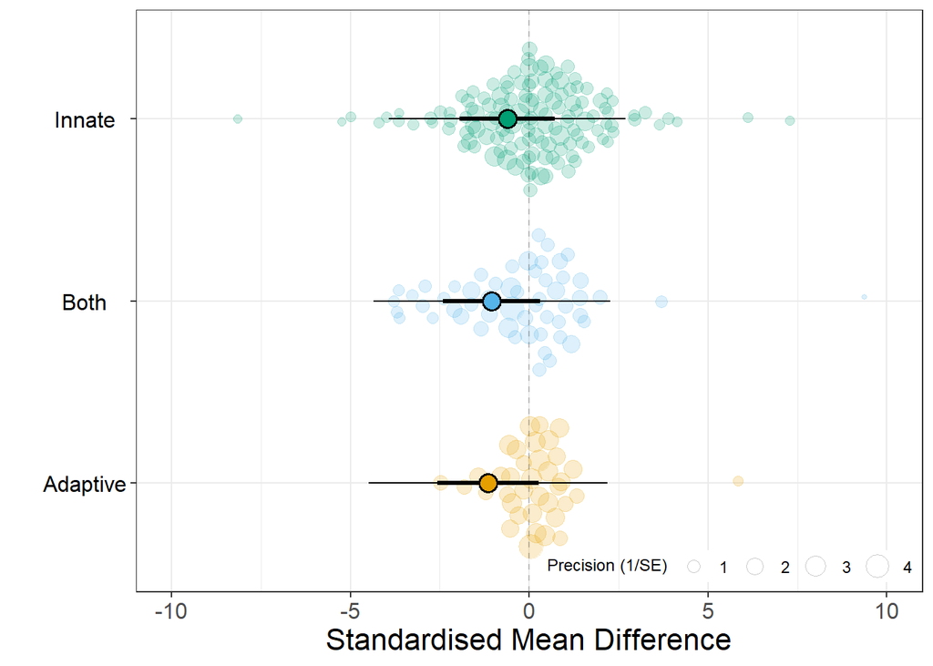

## Meta-analysis including thermoregulation type as a moderator:

Number of observations for each type:

```
##
## Ectothermic Endothermic
##          32         192
```

```
##
## Multivariate Meta-Analysis Model (k = 224; method: REML)
##
##    logLik   Deviance        AIC        BIC       AICc
## -383.0913   766.1827   780.1827   804.0014   780.7060
##
## Variance Components:
##
##             estim    sqrt  nlvls  fixed    factor
## sigma^2.1  0.7724  0.8788     17     no  Study_ID
## sigma^2.2  0.7097  0.8424      3     no     Class
## sigma^2.3  0.0000  0.0001      8     no    Family
## sigma^2.4  0.0000  0.0001     10     no   Species
## sigma^2.5  0.5726  0.7567    224     no     obsID
##
## Test for Residual Heterogeneity:
## QE(df = 222) = 718.5867, p-val < .0001
##
## Test of Moderators (coefficients 1:2):
## QM(df = 2) = 2.9885, p-val = 0.2244
##
## Model Results:
##
##                              estimate      se     zval    pval    ci.lb   ci.ub
## ThermoregulationEctothermic   -1.3734  0.7950  -1.7274  0.0841  -2.9316  0.1849
## ThermoregulationEndothermic    0.0601  0.8835   0.0681  0.9457  -1.6716  1.7918
##
## ThermoregulationEctothermic  .
## ThermoregulationEndothermic
##
## ---
## Signif. codes:  0 '***' 0.001 '**' 0.01 '*' 0.05 '.' 0.1 ' ' 1
```

```
##
## Multivariate Meta-Analysis Model (k = 224; method: REML)
##
##    logLik   Deviance        AIC        BIC       AICc
## -383.0913   766.1827   780.1827   804.0014   780.7060
##
## Variance Components:
##
##             estim    sqrt  nlvls  fixed    factor
## sigma^2.1  0.7724  0.8788     17     no  Study_ID
## sigma^2.2  0.7097  0.8424      3     no     Class
## sigma^2.3  0.0000  0.0001      8     no    Family
## sigma^2.4  0.0000  0.0001     10     no   Species
## sigma^2.5  0.5726  0.7567    224     no     obsID
##
## Test for Residual Heterogeneity:
## QE(df = 222) = 718.5867, p-val < .0001
##
## Test of Moderators (coefficients 1:2):
## QM(df = 2) = 2.9885, p-val = 0.2244
##
## Model Results:
##
##                              estimate      se     zval    pval    ci.lb   ci.ub
## ThermoregulationEctothermic   -1.3734  0.7950  -1.7274  0.0841  -2.9316  0.1849
## ThermoregulationEndothermic    0.0601  0.8835   0.0681  0.9457  -1.6716  1.7918
##
## ThermoregulationEctothermic  .
## ThermoregulationEndothermic
##
## ---
## Signif. codes:  0 '***' 0.001 '**' 0.01 '*' 0.05 '.' 0.1 ' ' 1
```

### Plot of results of thermoregulation meta-regression:

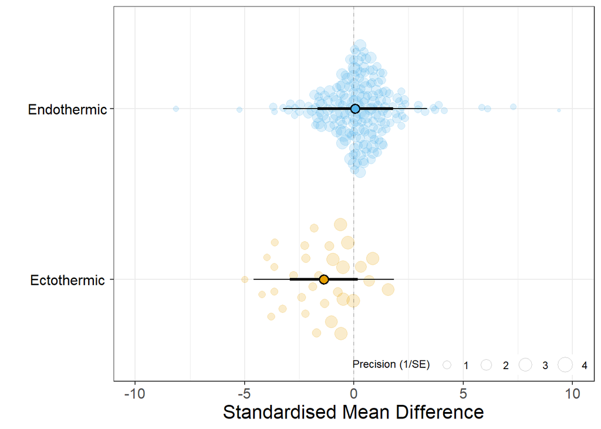

## Endotherms vs. ectotherms:

Now, we investigate if the response to hibernation varies across types of IM for endotherms and ectotherms. We include three types of immune function:

```
##
## Adaptive     Both   Innate
##       37       55      132
```

### Meta-model for endotherms:

- Number of observation with non-missing SMD: 192
- Number of studies in the dataset for analysis: 13
- Number of species in the dataset for analysis: 7

```
##
## Multivariate Meta-Analysis Model (k = 192; method: REML)
##
##    logLik   Deviance        AIC        BIC       AICc
## -329.5017   659.0034   671.0034   690.4539   671.4649
##
## Variance Components:
##
##             estim    sqrt  nlvls  fixed    factor
## sigma^2.1  0.6262  0.7913     13     no  Study_ID
## sigma^2.2  0.0000  0.0002      7     no   Species
## sigma^2.3  0.6102  0.7811    192     no     obsID
##
## Test for Residual Heterogeneity:
## QE(df = 189) = 567.1603, p-val < .0001
##
## Test of Moderators (coefficients 1:3):
## QM(df = 3) = 4.4493, p-val = 0.2169
##
## Model Results:
##
##                             estimate      se     zval    pval    ci.lb   ci.ub
## Biomarker_categoryAdaptive   -0.2185  0.3346  -0.6529  0.5138  -0.8744  0.4374
## Biomarker_categoryBoth       -0.1181  0.2807  -0.4206  0.6740  -0.6683  0.4321
## Biomarker_categoryInnate      0.3151  0.2745   1.1481  0.2509  -0.2228  0.8531
##
## Biomarker_categoryAdaptive
## Biomarker_categoryBoth
## Biomarker_categoryInnate
##
## ---
## Signif. codes:  0 '***' 0.001 '**' 0.01 '*' 0.05 '.' 0.1 ' ' 1
```

```
##
## Multivariate Meta-Analysis Model (k = 192; method: REML)
##
##    logLik   Deviance        AIC        BIC       AICc
## -329.5017   659.0034   671.0034   690.4539   671.4649
##
## Variance Components:
##
##             estim    sqrt  nlvls  fixed    factor
## sigma^2.1  0.6262  0.7913     13     no  Study_ID
## sigma^2.2  0.0000  0.0002      7     no   Species
## sigma^2.3  0.6102  0.7811    192     no     obsID
##
## Test for Residual Heterogeneity:
## QE(df = 189) = 567.1603, p-val < .0001
##
## Test of Moderators (coefficients 1:3):
## QM(df = 3) = 4.4493, p-val = 0.2169
##
## Model Results:
##
##                             estimate      se     zval    pval    ci.lb   ci.ub
## Biomarker_categoryAdaptive   -0.2185  0.3346  -0.6529  0.5138  -0.8744  0.4374
## Biomarker_categoryBoth       -0.1181  0.2807  -0.4206  0.6740  -0.6683  0.4321
## Biomarker_categoryInnate      0.3151  0.2745   1.1481  0.2509  -0.2228  0.8531
##
## Biomarker_categoryAdaptive
## Biomarker_categoryBoth
## Biomarker_categoryInnate
##
## ---
## Signif. codes:  0 '***' 0.001 '**' 0.01 '*' 0.05 '.' 0.1 ' ' 1
```

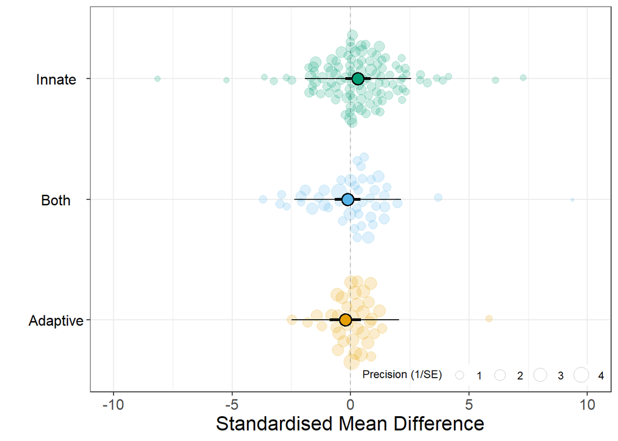

### Meta-model for ectotherms:

- Number of observation with non-missing SMD: 32
- Number of studies in the dataset for analysis: 4
- Number of species in the dataset for analysis: 3

```
##
## Multivariate Meta-Analysis Model (k = 32; method: REML)
##
##   logLik  Deviance       AIC       BIC      AICc
## -46.4386   92.8772  106.8772  116.6856  111.9681
##
## Variance Components:
##
##             estim    sqrt  nlvls  fixed    factor
## sigma^2.1  1.8742  1.3690      4     no  Study_ID
## sigma^2.2  0.0000  0.0003      2     no     Class
## sigma^2.3  0.0000  0.0000      3     no    Family
## sigma^2.4  0.0000  0.0000      3     no   Species
## sigma^2.5  0.4077  0.6385     32     no     obsID
##
## Test for Residual Heterogeneity:
## QE(df = 30) = 135.8328, p-val < .0001
##
## Test of Moderators (coefficients 1:2):
## QM(df = 2) = 3.7935, p-val = 0.1501
##
## Model Results:
##
##                           estimate      se     zval    pval    ci.lb   ci.ub
## Biomarker_categoryBoth     -1.5039  0.7858  -1.9139  0.0556  -3.0439  0.0362  .
## Biomarker_categoryInnate   -1.0577  0.7230  -1.4630  0.1435  -2.4748  0.3593
##
## ---
## Signif. codes:  0 '***' 0.001 '**' 0.01 '*' 0.05 '.' 0.1 ' ' 1
```

```
##
## Multivariate Meta-Analysis Model (k = 32; method: REML)
##
##   logLik  Deviance       AIC       BIC      AICc
## -46.4386   92.8772  106.8772  116.6856  111.9681
##
## Variance Components:
##
##             estim    sqrt  nlvls  fixed    factor
## sigma^2.1  1.8742  1.3690      4     no  Study_ID
## sigma^2.2  0.0000  0.0003      2     no     Class
## sigma^2.3  0.0000  0.0000      3     no    Family
## sigma^2.4  0.0000  0.0000      3     no   Species
## sigma^2.5  0.4077  0.6385     32     no     obsID
##
## Test for Residual Heterogeneity:
## QE(df = 30) = 135.8328, p-val < .0001
##
## Test of Moderators (coefficients 1:2):
## QM(df = 2) = 3.7935, p-val = 0.1501
##
## Model Results:
##
##                           estimate      se     zval    pval    ci.lb   ci.ub
## Biomarker_categoryBoth     -1.5039  0.7858  -1.9139  0.0556  -3.0439  0.0362  .
## Biomarker_categoryInnate   -1.0577  0.7230  -1.4630  0.1435  -2.4748  0.3593
##
## ---
## Signif. codes:  0 '***' 0.001 '**' 0.01 '*' 0.05 '.' 0.1 ' ' 1
```

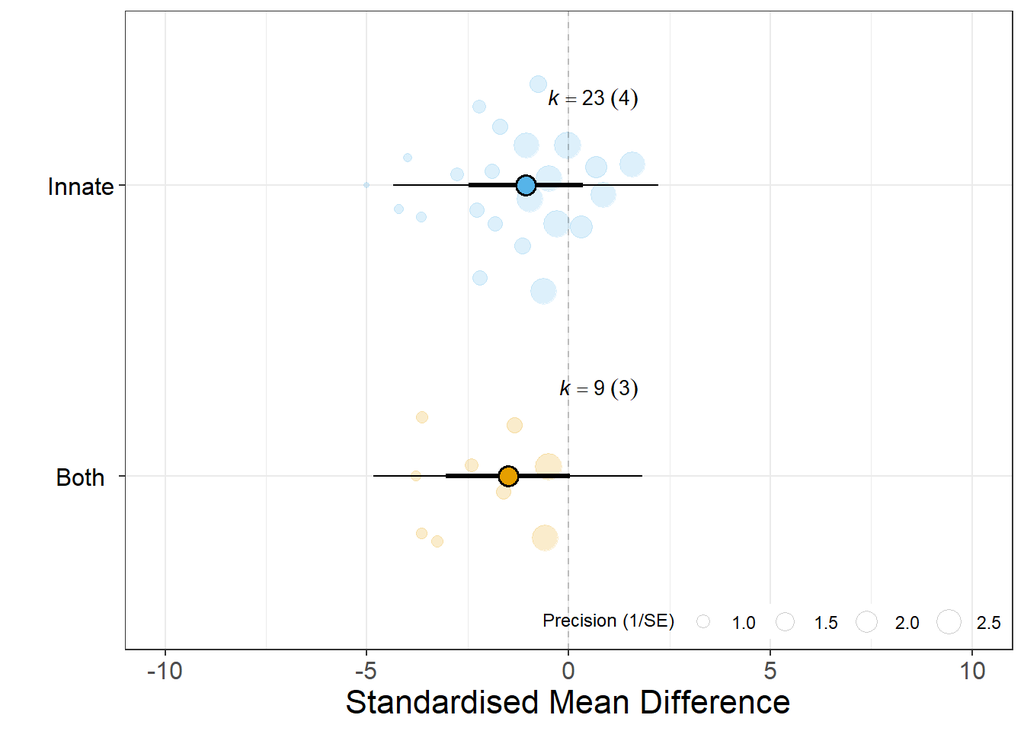